# finalProj

Joshua Smith Final Project CMSC320

This project investigates the hard to define concept of beauty in facial images. Instead of throwing a convolutional neural net at the problem and aiming for an accurate detector, we aim to make human-understandable observations on what might make someone be considered "more attractive". In order to do this, we will be reading in a dataset consisting of 5500 portraits, their corresponding beauty score on a scale of 1-5, and a set of facial keypoints for each portrait. We aim to make observations upon the relation between these facial keypoints and perceived attractiveness. I predict that there will be some slight correlations, but that the majority of what constitutes beauty will not be captured in only facial shape. In the paper linked below, where this dataset was derived from, a deep learning method on the input images was capable of achieving a pierson coefficient (r) of about 0.8. This will not be a benchmark we aim for however, because we are exploring a different explanatory variable. While deep learning methods are effective in terms of performance, they are hardly interpretable in terms of human logic, so it is hard to have any take-aways from the study.

```python
!mkdir data;
!pwd
!pip install opencv-python
!pip install torch
```

```
mkdir: cannot create directory ‘data’: File exists
/home/jovyan/notebooks/final
```

Now we need to download our dataset. This is the SCUT-FBP5500 dataset documented here: https://arxiv.org/pdf/1511.02459.pdf

The download link is here: https://drive.google.com/file/d/1w0TorBfTIqbquQVd6k3h_77ypnrvfGwf/view Once the zip is downloaded, unzip and place the 7 items in the data folder created above. This dataset was the result of a facial attractiveness study where pictures of people were presented to 60 raters, who rated the beauty of the portrait on a scale of 1-5. The dataset also contains pictures of the people, and locations of facial keypoints in each image - what we will be using. Run the below command to make sure the dataset data was correctly placed in the data folder. The items should be: All_Ratings.xlsx  
Images_Sources.xlsx  
train_test_files.zip 'facial landmark'  
README.txt Images  
train_test_files

```python
!ls
```

```
data  finalProj.ipynb
```

```python
import os
import pandas as pd
df = pd.DataFrame(columns=[4])
data = pd.read_csv("data/train_test_files/All_labels.txt", sep=" ", header=None);
data = data.rename(columns={0: "img", 1: "rating"});
```

```python
for i, row in data.iterrows():
    ident = row["img"][:-4]
    data.loc[i, "id"] = ident
    data.loc[i, "race"] = "white" if ident[0] == 'C' else "asian"
    data.loc[i, "gender"] = "male" if ident[1] == 'M' else "female"
print(data)
data = data[['id','rating', 'gender', 'race', 'img']]
```

```
             img    rating      id   race  gender
0      CF437.jpg  2.883333   CF437  white  female
1     AM1384.jpg  2.466667  AM1384  asian    male
2     AM1234.jpg  2.150000  AM1234  asian    male
3     AM1774.jpg  3.750000  AM1774  asian    male
4      CF215.jpg  3.033333   CF215  white  female
...          ...       ...     ...    ...     ...
5495   AF546.jpg  1.883333   AF546  asian  female
5496   AM558.jpg  2.766667   AM558  asian    male
5497   AF805.jpg  2.450000   AF805  asian  female
5498   AF271.jpg  3.233333   AF271  asian  female
5499  AM1535.jpg  2.066667  AM1535  asian    male

[5500 rows x 5 columns]
```

```python
data
```

|  | id | rating | gender | race | img |
| --- | --- | --- | --- | --- | --- |
| 0 | CF437 | 2.883333 | female | white | CF437.jpg |
| 1 | AM1384 | 2.466667 | male | asian | AM1384.jpg |
| 2 | AM1234 | 2.150000 | male | asian | AM1234.jpg |
| 3 | AM1774 | 3.750000 | male | asian | AM1774.jpg |
| 4 | CF215 | 3.033333 | female | white | CF215.jpg |
| ... | ... | ... | ... | ... | ... |
| 5495 | AF546 | 1.883333 | female | asian | AF546.jpg |
| 5496 | AM558 | 2.766667 | male | asian | AM558.jpg |
| 5497 | AF805 | 2.450000 | female | asian | AF805.jpg |
| 5498 | AF271 | 3.233333 | female | asian | AF271.jpg |
| 5499 | AM1535 | 2.066667 | male | asian | AM1535.jpg |

5500 rows × 5 columns

In the above code, we have read the ratings file and created a dataset with the gender/race as well as their corresponding image id. Now lets define a function that given a img filename will load the image. We will test to see that the documented traits match the image. Also, lets try displaying the image with the highest beauty score.

```
id            AF1973
rating          4.75
gender        female
race           asian
img       AF1973.jpg
Name: 3784, dtype: object
```

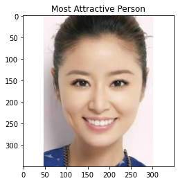

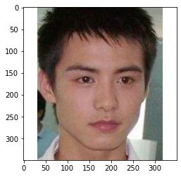

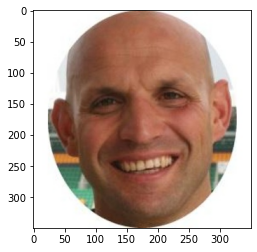

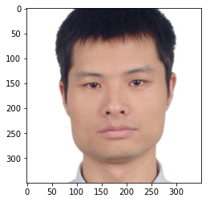

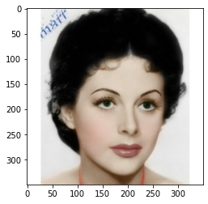

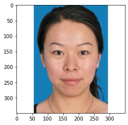

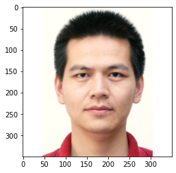

[figure not shown]

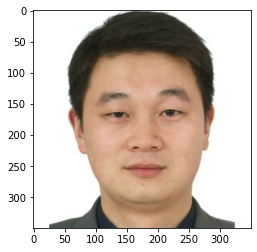

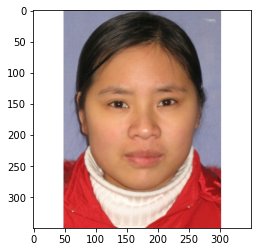

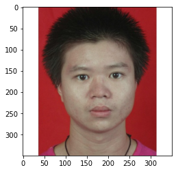

```python
import cv2
import numpy as np
import matplotlib.pyplot as plt
def load_image(filename):
    full_path = './data/Images/'+filename
    img = cv2.cvtColor(cv2.imread(full_path), cv2.COLOR_BGR2RGB)
    return img

highest_index = data['rating'].argmax()
img = load_image(data['img'][highest_index])
plt.imshow(img)
plt.title("Most Attractive Person")
print(data.iloc[highest_index])
plt.show()
for i in range(10):
    index = 100 + i
    img = load_image(data['img'][index])
    plt.imshow(img)
    plt.show()
```

Evidently, the data read in worked correctly as the attributes matched with the corresponding image. Looking at the variety of the images, we can see that they were taken with slightly different distances away from the camera and with different tilts. Because of this, the facial keypoints provided by the dataset will not be an objective measure of the persons face structure, so we will have to look at relative pose measures to create traits that could potentially inform us about the person. without scaling via ratios, if we were to look at pixel inter-pupillary distance, somebody with wide eyes farther from the camera may have the same ipd value as someone with close eyes who was pictured closer to the camera. First, we will need to read in the facial keypoints data provided in .pts files. This was done by reading in each file according to the participant id, then unpacking it into is 172 length points vector, which was reshaped to by 86x2 vector representing 86 points.

```python
import struct
pt_list = []
index = 0
for i, row in data.iterrows():
    pt_fn = './data/facial landmark/' + row['id'] + '.pts'
    pts_data = open(pt_fn, encoding="ISO-8859-1").read()
    if len(pts_data) == 692: #not all point files are complete, dont include those ones
        points = struct.unpack('i172f', bytes(pts_data, "ISO-8859-1"))
        new_pts = []
        for g in range(len(points)//2):
            new_pts.append([points[1 + (2*g)], points[2 + (2*g)]])
        data.loc[i, "pt_i"] = int(index)
        index += 1
    pt_list.append(new_pts)

pts = np.array(pt_list)
```

```python
data
```

|  | id | rating | gender | race | img | pt_i |
| --- | --- | --- | --- | --- | --- | --- |
| 0 | CF437 | 2.883333 | female | white | CF437.jpg | 0.0 |
| 1 | AM1384 | 2.466667 | male | asian | AM1384.jpg | 1.0 |
| 2 | AM1234 | 2.150000 | male | asian | AM1234.jpg | 2.0 |
| 3 | AM1774 | 3.750000 | male | asian | AM1774.jpg | 3.0 |
| 4 | CF215 | 3.033333 | female | white | CF215.jpg | 4.0 |
| ... | ... | ... | ... | ... | ... | ... |
| 5495 | AF546 | 1.883333 | female | asian | AF546.jpg | 5494.0 |
| 5496 | AM558 | 2.766667 | male | asian | AM558.jpg | 5495.0 |
| 5497 | AF805 | 2.450000 | female | asian | AF805.jpg | 5496.0 |
| 5498 | AF271 | 3.233333 | female | asian | AF271.jpg | 5497.0 |
| 5499 | AM1535 | 2.066667 | male | asian | AM1535.jpg | 5498.0 |

5500 rows × 6 columns

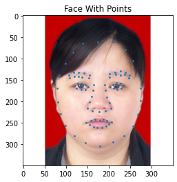

```python
highest_index = 60
index = data['pt_i'][highest_index]
img = load_image(data['img'][highest_index])
face_points = pts[int(index)]
val = [66] #54 is right ipd, #42 is left ipd
#plt.scatter(face_points[val,0], face_points[val,1], 3) #this was used to display single points and determine
#what indexes mapped to certain regions of the face.
plt.scatter(face_points[:,0], face_points[:,1], 3)
plt.imshow(img)
plt.title("Face With Points")
plt.show()
```

Here is an example of the face points plotted on their corresponding portrait. Luckily, they match up with the corresponding image very closely, so we can proceed. As you can see in the commented out code, in the experimental phase of this project I was plotting a single point at a time. This allowed me to figure out what points indexes mapped to what points on the face. This was a painstaking process, but the authors of the paper linked above who created this dataset did not provide explicit documentation for the points layout, so I had to discover it myself. These specific face point values will be used later to calculate traits such as inter-pupillary distance and nose height. Before this, however, lets start by doing some analysis on this collected data. Lets look at the distribution of ratings, and categorize them by gender to see if there is any difference.

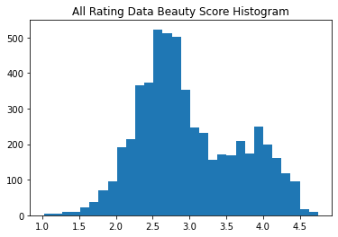

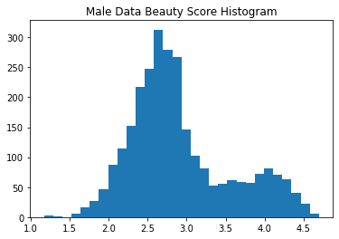

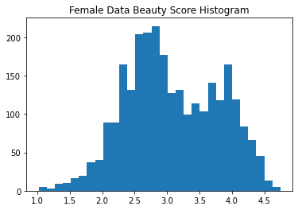

```
Male Score Mean: 2.9045333374545472, Std: 0.6496372263763964
Female Score Mean: 3.077248485818185, Std: 0.7140580842433036
```

```python
plt.title('All Rating Data Beauty Score Histogram')
plt.hist(data['rating'], 30);
plt.show()

plt.title('Male Data Beauty Score Histogram')
plt.hist(data['rating'][data.gender.isin(['male'])], 30);
plt.show()

plt.title('Female Data Beauty Score Histogram')
plt.hist(data['rating'][data.gender.isin(['female'])], 30);
plt.show()

print("Male Score Mean: {}, Std: {}".format(np.mean(data['rating'][data.gender.isin(['male'])]), np.std(data['rating'][data.gender.isin(['male'])])))
print("Female Score Mean: {}, Std: {}".format(np.mean(data['rating'][data.gender.isin(['female'])]), np.std(data['rating'][data.gender.isin(['female'])])))
```

I created histograms by running plt.hist. The male and female histograms were generated by using a conditional mask over the dataframe data before inputting into the hist funciton. Interestingly, the beauty histogram does not represent a normal distribution but rather appears bimodal. This would suggest that instead of it being a smooth slope, people are often viewed as either "beautiful" or not, with a valley inbetween. According to the means above, Men are rated slightly lower on average, and have a tighter distribution according to the std. I have heard before that there are fewer attractive men than women, and while I am not necessarily sold on that observation, these histograms marginally bolster the argument. (Only marginally because the difference between a standard deviation of 0.714 and 0.650 is not large.)

```python
def get_dist(p1, p2):
    return np.sqrt(((p1[0] - p2[0])*(p1[0] - p2[0])) + ((p1[1] - p2[1])*(p1[1] - p2[1])))

for i, row in data.iterrows():
    index = data['pt_i'][i]
    if not (index >= 0):
        continue
    points = pts[int(index)]
    data.loc[i, "face_width"] = np.max(points[:,0]) - np.min(points[:,0])
    data.loc[i, "face_height"] = np.max(points[:,1]) - np.min(points[:,1])
    data.loc[i, "eye_width"] = get_dist(points[58], points[59])
    data.loc[i, "eye_height"] = get_dist(points[11], (points[58] + points[59])/2)
    data.loc[i, "lip_height"] = get_dist(points[11], points[76])
    data.loc[i, "lip_width"] = get_dist(points[79], points[73])
    data.loc[i, "nose_width"] = get_dist(points[68], points[64])
    data.loc[i, "nose_height"] = get_dist(points[11], points[66])

        #next we will get the ratios for all of the values, because objective pixel value depend on photo zoom/external factors
    data.loc[i, "face_r"] = data['face_width'][i] / data['face_height'][i]
    data.loc[i, "eye_width_r"] = data['eye_width'][i] / data['face_width'][i]
    data.loc[i, "eye_height_r"] = data['eye_height'][i] / data['face_height'][i]
    data.loc[i, "lip_width_r"] = data['lip_width'][i] / data['face_width'][i]
    data.loc[i, "lip_height_r"] = data['lip_height'][i] / data['face_height'][i]
    data.loc[i, "nose_width_r"] = data['nose_width'][i] / data['face_width'][i]
    data.loc[i, "nose_height_r"] = data['nose_height'][i] / data['face_height'][i]
```

As mentioned before, raw pixel values will be effected by the pose and orientation of the person in the photo. In order to make standardized values, we can compute ratios of face distances in relation to overall head width or height. For example, if a person's inter-pupilary distance is half of their head width, this value will not change significantly whether they are far or close from the camera. Specifically, I computed the ratio between face width and face height, the ratio between eye width and face width, the ratio between how high the eyes are placed and face height, the ratio between lip width and face width, the ratio between lip height and face height, the ratio between nose width and face width, and finally the ratio between nose height and face height.

```python
data
```

|  | id | rating | gender | race | img | pt_i | face_width | face_height | eye_width | eye_height | ... | lip_width | nose_width | nose_height | face_r | eye_width_r | eye_height_r | lip_width_r | lip_height_r | nose_width_r | nose_height_r |
| --- | --- | --- | --- | --- | --- | --- | --- | --- | --- | --- | --- | --- | --- | --- | --- | --- | --- | --- | --- | --- | --- |
| 0 | CF437 | 2.883333 | female | white | CF437.jpg | 0.0 | 202.0 | 281.0 | 94.429868 | 171.345411 | ... | 85.375641 | 62.801274 | 90.669730 | 0.718861 | 0.467475 | 0.609770 | 0.422652 | 0.268418 | 0.310897 | 0.322668 |
| 1 | AM1384 | 2.466667 | male | asian | AM1384.jpg | 1.0 | 191.0 | 264.0 | 87.022985 | 158.000791 | ... | 64.031242 | 58.000000 | 87.051709 | 0.723485 | 0.455618 | 0.598488 | 0.335242 | 0.265260 | 0.303665 | 0.329741 |
| 2 | AM1234 | 2.150000 | male | asian | AM1234.jpg | 2.0 | 194.0 | 225.0 | 83.000000 | 147.007653 | ... | 62.000000 | 54.009258 | 81.000000 | 0.862222 | 0.427835 | 0.653367 | 0.319588 | 0.284444 | 0.278398 | 0.360000 |
| 3 | AM1774 | 3.750000 | male | asian | AM1774.jpg | 3.0 | 177.0 | 245.0 | 82.000000 | 140.000000 | ... | 66.007575 | 56.000000 | 69.007246 | 0.722449 | 0.463277 | 0.571429 | 0.372924 | 0.236735 | 0.316384 | 0.281662 |
| 4 | CF215 | 3.033333 | female | white | CF215.jpg | 4.0 | 237.0 | 294.0 | 106.301458 | 188.087745 | ... | 99.247166 | 67.911707 | 107.786827 | 0.806122 | 0.448529 | 0.639754 | 0.418764 | 0.282395 | 0.286547 | 0.366622 |
| ... | ... | ... | ... | ... | ... | ... | ... | ... | ... | ... | ... | ... | ... | ... | ... | ... | ... | ... | ... | ... | ... |
| 5495 | AF546 | 1.883333 | female | asian | AF546.jpg | 5494.0 | 188.0 | 247.0 | 82.006097 | 149.503344 | ... | 69.028979 | 53.084838 | 78.102497 | 0.761134 | 0.436203 | 0.605277 | 0.367175 | 0.279821 | 0.282366 | 0.316204 |
| 5496 | AM558 | 2.766667 | male | asian | AM558.jpg | 5495.0 | 184.0 | 238.0 | 84.005952 | 139.503584 | ... | 78.006410 | 58.077534 | 77.006493 | 0.773109 | 0.456554 | 0.586150 | 0.423948 | 0.252101 | 0.315639 | 0.323557 |
| 5497 | AF805 | 2.450000 | female | asian | AF805.jpg | 5496.0 | 174.0 | 225.0 | 78.057671 | 140.503559 | ... | 60.008333 | 55.000000 | 81.055537 | 0.773333 | 0.448607 | 0.624460 | 0.344875 | 0.280317 | 0.316092 | 0.360247 |
| 5498 | AF271 | 3.233333 | female | asian | AF271.jpg | 5497.0 | 154.0 | 198.0 | 69.007246 | 111.501121 | ... | 54.037024 | 46.010868 | 58.008620 | 0.777778 | 0.448099 | 0.563137 | 0.350890 | 0.217230 | 0.298772 | 0.292973 |
| 5499 | AM1535 | 2.066667 | male | asian | AM1535.jpg | 5498.0 | 183.0 | 245.0 | 78.057671 | 139.628973 | ... | 67.119297 | 54.037024 | 74.108029 | 0.746939 | 0.426545 | 0.569914 | 0.366772 | 0.257175 | 0.295284 | 0.302482 |

5500 rows × 21 columns

Alright, now we have a bunch of face values, and by standardizing with respect to overall head size we can compare different people directly. Lets plot rating versus trait for all of these different values. I am expecting very low correlations.

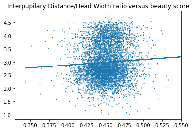

```
2.1343170578020976
```

```python
data = data.drop(3566) #drop the one value that had Nan face measurement values

plt.title("Interpupilary Distance/Head Width ratio versus beauty score")
plt.xlim(.33, .55)
plt.scatter(data['eye_width_r'], data['rating'], 1)
m, b = np.polyfit(data['eye_width_r'], data['rating'], 1)
plt.plot(data['eye_width_r'], m*data['eye_width_r'] + b)
plt.show()
print(m)
```

Evidently, having wider eyes is marginally beneficial for your beauty score. In this fit, increasing the ratio by 0.1 will increase your beauty score by 0.2134. Lets plot some other ratios.

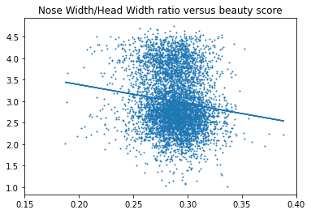

```
-4.494776495407
```

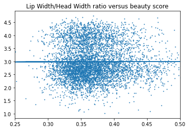

```
0.045486388158329324
```

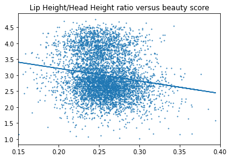

```
-3.9275508070725045
```

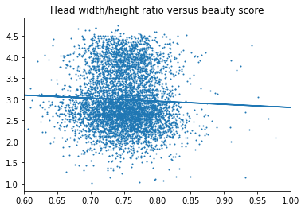

```
-0.7284233734341524
```

```python
plt.title("Nose Width/Head Width ratio versus beauty score")
plt.xlim(0.15, .4)
plt.scatter(data['nose_width_r'], data['rating'], 1)
m, b = np.polyfit(data['nose_width_r'], data['rating'], 1)
plt.plot(data['nose_width_r'], m*data['nose_width_r'] + b)

plt.show()
print(m)

plt.title("Lip Width/Head Width ratio versus beauty score")
plt.xlim(0.25, .5)
plt.scatter(data['lip_width_r'], data['rating'], 1)
m, b = np.polyfit(data['lip_width_r'], data['rating'], 1)
plt.plot(data['lip_width_r'], m*data['lip_width_r'] + b)

plt.show()
print(m)

plt.title("Lip Height/Head Height ratio versus beauty score")
plt.xlim(0.15, .4)
plt.scatter(data['lip_height_r'], data['rating'], 1)
m, b = np.polyfit(data['lip_height_r'], data['rating'], 1)
plt.plot(data['lip_height_r'], m*data['lip_height_r'] + b)

plt.show()
print(m)

plt.title("Head width/height ratio versus beauty score")
plt.xlim(0.6, 1)
plt.scatter(data['face_r'], data['rating'], 1)
m, b = np.polyfit(data['face_r'], data['rating'], 1)
plt.plot(data['face_r'], m*data['face_r'] + b)

plt.show()
print(m)
```

Evidently, we found some significant correlations between facial structure attributes and perceived attractiveness. The width of someones nose, when standardized by face width, has a negative correlation corresponding to a decrease of 0.45 in beauty score for every 0.1 increase in nose to face width ratio. Lip width did not have a significant correlation with the beauty score. Lip height (distance from chin) had a negative correlation with beauty score, suggesting that a smaller chin is considered more attractive in general. The overall head width/height ratio had a weak regression suggesting that having a skinnier head is slightly more attractive, but not as significant as other factors previously studied. Now lets make a multi-linear regression

```python
from sklearn import linear_model
clf = linear_model.LinearRegression()
d = np.array(data[["face_width", "face_height", "eye_width", "eye_height", "lip_width", "lip_height", "nose_width", "nose_height", "face_r", "eye_width_r", "eye_height_r", "lip_width_r", "lip_height_r", "nose_width_r", "nose_height_r"]])
y = np.array(data['rating'])
clf.fit(d,y)
print(clf.coef_)
print(clf.intercept_)
print(clf.score(d,np.array(data['rating'])))
pred = clf.predict(d)
mse = np.sum((np.array(data['rating']) - pred)*(np.array(data['rating']) - pred))/len(d)
print("mse: {}".format(mse))
```

```
[ 1.59056759e-02 -1.36025383e-02  4.63790116e-03 -2.18606409e-02
 -3.26317049e-02 -6.27517376e-02  8.16805414e-02  5.89309172e-02
 -1.07260044e+01 -8.24310708e-01  1.40939937e+01  7.75063465e+00
  1.82460818e+01 -2.39665120e+01 -2.63407321e+01]
11.31766618810178
0.11787728154413268
mse: 0.41746164382906475
```

After making a multi-linear regression on the face attributes, we can see that the r^2 is only 0.11787. Maybe we can improve this by adding a gender and race encoding. Our exploratory analysis suggested that women were perceived as more attractive on average compared to men, so this should be useful information for the classifier.

```python
for i, row in data.iterrows():
    data.loc[i, "male_encode"] = 1 if row['gender'] == 'male' else 0
    data.loc[i, "white_encode"] = 1 if row['race'] == 'white' else 0
```

```python
clf = linear_model.LinearRegression()
d = np.array(data[["face_width", "face_height", "eye_width", "eye_height", "lip_width", "lip_height", "nose_width", "nose_height", "face_r", "eye_width_r", "eye_height_r", "lip_width_r", "lip_height_r", "nose_width_r", "nose_height_r", "male_encode", "white_encode"]])
clf.fit(d,np.array(data['rating']))
print(clf.coef_)
print(clf.intercept_)
print(clf.score(d,np.array(data['rating'])))
pred = clf.predict(d)
mse = np.sum((np.array(data['rating']) - pred)*(np.array(data['rating']) - pred))/len(data['rating'])
print("mse: {}".format(mse))
```

```
[ 1.65294779e-02 -1.21296936e-02  1.02828798e-02 -2.38048736e-02
 -3.50433980e-02 -6.00509022e-02  7.88762178e-02  5.09498721e-02
 -1.12007968e+01 -2.20007910e+00  1.45789567e+01  7.79278212e+00
  1.71514178e+01 -2.23751239e+01 -2.38043401e+01 -9.51803507e-02
  1.38435157e-01]
11.124147439414658
0.12819060292471218
mse: 0.4125808987730813
```

Adding these encodings did help slightly! Now the R^2 is .128, meaning that 12.8% of variation can be explained by our predictor, which is pretty good for real world data on something as qualitative as perceived beauty. Given that there are at most 17 trainable parameters in the above 2 models, we haven't had to worry about overfitting on a >5000 points dataset. I implemented other models including a fully connected neural net in pytorch, but accuracy did not exceed that of the multi-linear fit so either my fcn implementation was flawed (I spent many hours attempting to debug it) or the linear regression was simply a better solution for the classification problem.

Conclusions:

To summarize, we read in the dataset data and formatted it into a pandas dataframe. Then we did some exploratory analysis on the data, viewing histograms of beauty ratings. Then, we designed our own features based on facial keypoints, distances between them, and relative ratios. This gave us a means of comparing the people in our dataset objectively according to facial structure ratios. We did a variety of single variate fits to find which attributes correlated with beauty score. Interestingly, having a skinny nose and a small chin (low lip height) were found to be the most effective qualities in improving beauty score. Finally, we did 2 multi-linear fits on the data, which allowed us to achieve .12 r^2 on the beauty score. This means that by simply knowing the positions of keypoints on somebody's face, we can predict 12% of the beauty score reliably, with the other 88% not being captured by the linear fit. However, considering we used facial keypoints and not actual images, the majority of information that dictates qualitative "beauty" were withheld, so I was happy with a 0.12 r^2. Overall, this study revealed correlations with perceived facial beauty that I was unaware of, but certainly find interesting. While some might criticise trying to automate the detection of something that is in "the eye of the beholder" this study does investigate an important issue. Physical looks are an extremely impactful force in every aspect of our lives, even in places where it shouldn't be, like a professional workplace. Studies have shown attractive people are perceived as more intelligent, trustworthy, and are more upwardly mobile in the workplace. Therefore, attempting to formally understand what constitutes "beauty" has its merits.